# IMPUTATION METHODS(HEART DISEASE)

CHRISTINA THOMPSON ACQUAH

# 1 **Introduction**

Missing values are a common issue in data analysis and machine learning, often resulting from data collection errors, equipment failures, or participant non-response in surveys. If not handled properly, missing data can lead to biased statistical estimates, reduced model accuracy, and unreliable predictions. Therefore, appropriate imputation techniques are necessary to ensure data completeness and improve model performance.

## 1.1 **Summary of Missing Value Imputation (Part I)**

In the first part of this project, we explored four different approaches to handling missing values in a dataset:

1. **Mode Imputation**: Replaced missing categorical values with the most frequently occurring category.
2. **K-Nearest Neighbors (KNN) Imputation**: Used similarity-based learning to estimate missing categorical values.
3. **Regression-Based Imputation**: Predicted missing numerical values using regression models, incorporating random error for variability.
4. **Multiple Imputation (MICE)**: Created multiple plausible datasets by iteratively imputing missing values.

Each method was evaluated based on its impact on data completeness and its effectiveness in preserving statistical relationships.

## 1.2 **Feature Engineering for Model Improvement (Part II)**

Now, in this second part of the project, we focus on **feature engineering**—transforming, selecting, and creating new features to improve model performance.

### 1.2.1 **Observations from project #1**

Exploratory Data Analysis (EDA) from **Project #1** revealed key feature-related issues that need to be addressed:

## 1.3 **Implications**

- **Skewness correction** ensures that features better conform to assumptions of normality in regression-based models.
- **Scaling & standardization** allow machine learning models to process variables more effectively, especially for distance-based algorithms.
- **Feature selection** helps prevent overfitting, reducing computational cost while maintaining model accuracy.
- **Feature creation** enables models to capture **hidden patterns** in the data, improving predictive performance.

Properly applying these feature engineering techniques **enhances the dataset’s quality**, leading to better model generalization and interpretability.

### 1.3.1 **Next Steps**

The upcoming sections will:

1. **Transform numerical variables** to correct skewness and improve distribution consistency.
2. **Select key features** based on statistical relevance and model requirements.
3. **Create new meaningful features** where needed to enhance model performance.

Each technique will be implemented to ensure structure improvements to the dataset.

# 2 ** Replacement Imputation for Categorical Features**

This section covers two techniques for handling missing values in categorical features:

### 2.0.1 Mode Imputation

- **Definition:** A simple approach where missing values are replaced with the most frequently occurring category.
- **Steps:**
  - Identify categorical columns.
  - Calculate the mode for each column.
  - Replace missing values with the mode.
- **Advantages:** Fast and efficient.
- **Limitations:** May introduce bias if the dominant category is not representative.

**Summary:**

### 2.0.2 **Findings:**

- Categorical variables such as `Gender` and `Exercise_Habits` contained missing values.
- **Mode Imputation** replaces missing values with the **most frequent category** in each variable.

### 2.0.3 **Results:**

- Mode imputation successfully replaced missing values **without introducing new categories**.
- It is a **quick and effective approach** when missingness is minimal.
- However, this method **can introduce bias** if the most frequent category is **overrepresented** in the dataset.

### 2.0.4 **Implications:**

- Suitable for cases where missing values occur **randomly (MCAR)** and in **small proportions**.
- **Less effective** for datasets with **complex patterns** in missingness.

```r
library(tidyverse)

# Loading the dataset
heart_df<-read.csv("https://raw.githubusercontent.com/Christina-tinaa/Heart-Disease/main/heart_disease.csv")

# View summary to identify missing values
summary(heart_df)
```

```
      Age          Gender          Blood.Pressure  Cholesterol.Level
 Min.   :18.0   Length:10000       Min.   :120.0   Min.   :150.0
 1st Qu.:34.0   Class :character   1st Qu.:134.0   1st Qu.:187.0
 Median :49.0   Mode  :character   Median :150.0   Median :226.0
 Mean   :49.3                      Mean   :149.8   Mean   :225.4
 3rd Qu.:65.0                      3rd Qu.:165.0   3rd Qu.:263.0
 Max.   :80.0                      Max.   :180.0   Max.   :300.0
 NA's   :29                        NA's   :19      NA's   :30
 Exercise.Habits      Smoking          Family.Heart.Disease   Diabetes
 Length:10000       Length:10000       Length:10000         Length:10000
 Class :character   Class :character   Class :character     Class :character
 Mode  :character   Mode  :character   Mode  :character     Mode  :character




      BMI        High.Blood.Pressure Low.HDL.Cholesterol High.LDL.Cholesterol
 Min.   :18.00   Length:10000        Length:10000        Length:10000
 1st Qu.:23.66   Class :character    Class :character    Class :character
 Median :29.08   Mode  :character    Mode  :character    Mode  :character
 Mean   :29.08
 3rd Qu.:34.52
 Max.   :40.00
 NA's   :22
 Alcohol.Consumption Stress.Level        Sleep.Hours     Sugar.Consumption
 Length:10000        Length:10000       Min.   : 4.001   Length:10000
 Class :character    Class :character   1st Qu.: 5.450   Class :character
 Mode  :character    Mode  :character   Median : 7.003   Mode  :character
                                        Mean   : 6.991
                                        3rd Qu.: 8.532
                                        Max.   :10.000
                                        NA's   :25
 Triglyceride.Level Fasting.Blood.Sugar   CRP.Level         Homocysteine.Level
 Min.   :100.0      Min.   : 80.0       Min.   : 0.003647   Min.   : 5.000
 1st Qu.:176.0      1st Qu.: 99.0       1st Qu.: 3.674126   1st Qu.: 8.723
 Median :250.0      Median :120.0       Median : 7.472164   Median :12.409
 Mean   :250.7      Mean   :120.1       Mean   : 7.472201   Mean   :12.456
 3rd Qu.:326.0      3rd Qu.:141.0       3rd Qu.:11.255592   3rd Qu.:16.141
 Max.   :400.0      Max.   :160.0       Max.   :14.997087   Max.   :19.999
 NA's   :26         NA's   :22          NA's   :26          NA's   :20
 Heart.Disease.Status
 Length:10000
 Class :character
 Mode  :character
```

```r
# Identify categorical columns
categorical_cols <- heart_df %>%
  select(where(is.factor), where(is.character))

# Function to compute mode
mode_impute <- function(x) {
  ux <- unique(na.omit(x)) # Remove NA values
  ux[which.max(tabulate(match(x, ux)))] # Find most frequent value
}

# Apply Mode Imputation directly to categorical columns in heart_df
heart_df <- heart_df %>%
  mutate(across(all_of(colnames(categorical_cols)), ~replace_na(., mode_impute(.))))

# Verify missing values after imputation
colSums(is.na(heart_df))
```

```
                 Age               Gender       Blood.Pressure
                  29                    0                   19
   Cholesterol.Level      Exercise.Habits              Smoking
                  30                    0                    0
Family.Heart.Disease             Diabetes                  BMI
                   0                    0                   22
 High.Blood.Pressure  Low.HDL.Cholesterol High.LDL.Cholesterol
                   0                    0                    0
 Alcohol.Consumption         Stress.Level          Sleep.Hours
                   0                    0                   25
   Sugar.Consumption   Triglyceride.Level  Fasting.Blood.Sugar
                   0                   26                   22
           CRP.Level   Homocysteine.Level Heart.Disease.Status
                  26                   20                    0
```

```r
# View a sample of the cleaned categorical features
print(head(heart_df[colnames(categorical_cols)]))
```

```
  Gender Exercise.Habits Smoking Family.Heart.Disease Diabetes
1   Male            High     Yes                  Yes       No
2 Female            High      No                  Yes      Yes
3   Male             Low      No                   No       No
4 Female            High     Yes                  Yes       No
5   Male             Low     Yes                  Yes      Yes
6   Male             Low     Yes                   No       No
  High.Blood.Pressure Low.HDL.Cholesterol High.LDL.Cholesterol
1                 Yes                 Yes                   No
2                  No                 Yes                   No
3                  No                 Yes                  Yes
4                 Yes                  No                  Yes
5                 Yes                  No                   No
6                  No                  No                   No
  Alcohol.Consumption Stress.Level Sugar.Consumption Heart.Disease.Status
1                High       Medium            Medium                   No
2              Medium         High            Medium                   No
3                 Low          Low               Low                   No
4                 Low         High              High                   No
5                 Low         High              High                   No
6                 Low       Medium               Low                   No
```

### 2.0.5 K-Nearest Neighbors (KNN) Imputation

- **Definition:** This method imputes missing values based on the most common category among the k-nearest neighbors (with k=5).
- **Steps:**
  - Convert categorical variables to dummy variables (one-hot encoding).
  - Apply the KNN algorithm to find neighbors.
  - Impute missing values using the most frequent category from the neighbors.
- **Advantages:** Preserves patterns and relationships between features.
- **Limitations:** Computationally intensive and sensitive to outliers.

**Summary:**

### 2.0.6 **Findings:**

- KNN Imputation replaces missing categorical values by finding the most common category among **k-nearest neighbors**.
- We used **k = 5**, meaning the five closest observations were considered for imputation.

### 2.0.8 **Implications:**

- More **flexible and data-driven** compared to Mode Imputation.
- Suitable when **data relationships can guide imputation**.
- May **not work well for sparse datasets** or when missing values are concentrated in specific subgroups.

```r
if (!require(VIM)) {
  install.packages("VIM")
  library(VIM)
}

# Identify categorical columns with missing values
categorical_cols <- heart_df %>%
  select(where(is.factor), where(is.character)) %>%
  colnames()  # Convert to a character vector

# Apply KNN Imputation for Categorical Features
set.seed(123)  # Ensures reproducibility
heart_df_knn <- kNN(heart_df, variable = categorical_cols, k = 5)

# Drop extra columns created by kNN() (which track imputed values)
heart_df_knn <- heart_df_knn %>% select(-starts_with("imp_"))

# Verify missing values after imputation
colSums(is.na(heart_df_knn))
```

```
                     Age                   Gender           Blood.Pressure
                      29                        0                       19
       Cholesterol.Level          Exercise.Habits                  Smoking
                      30                        0                        0
    Family.Heart.Disease                 Diabetes                      BMI
                       0                        0                       22
     High.Blood.Pressure      Low.HDL.Cholesterol     High.LDL.Cholesterol
                       0                        0                        0
     Alcohol.Consumption             Stress.Level              Sleep.Hours
                       0                        0                       25
       Sugar.Consumption       Triglyceride.Level      Fasting.Blood.Sugar
                       0                       26                       22
               CRP.Level       Homocysteine.Level     Heart.Disease.Status
                      26                       20                        0
              Gender_imp      Exercise.Habits_imp              Smoking_imp
                       0                        0                        0
Family.Heart.Disease_imp             Diabetes_imp  High.Blood.Pressure_imp
                       0                        0                        0
 Low.HDL.Cholesterol_imp High.LDL.Cholesterol_imp  Alcohol.Consumption_imp
                       0                        0                        0
        Stress.Level_imp    Sugar.Consumption_imp Heart.Disease.Status_imp
                       0                        0                        0
```

```r
# View a sample of the cleaned categorical features
print(head(heart_df_knn %>% select(all_of(categorical_cols))))
```

```
  Gender Exercise.Habits Smoking Family.Heart.Disease Diabetes
1   Male            High     Yes                  Yes       No
2 Female            High      No                  Yes      Yes
3   Male             Low      No                   No       No
4 Female            High     Yes                  Yes       No
5   Male             Low     Yes                  Yes      Yes
6   Male             Low     Yes                   No       No
  High.Blood.Pressure Low.HDL.Cholesterol High.LDL.Cholesterol
1                 Yes                 Yes                   No
2                  No                 Yes                   No
3                  No                 Yes                  Yes
4                 Yes                  No                  Yes
5                 Yes                  No                   No
6                  No                  No                   No
  Alcohol.Consumption Stress.Level Sugar.Consumption Heart.Disease.Status
1                High       Medium            Medium                   No
2              Medium         High            Medium                   No
3                 Low          Low               Low                   No
4                 Low         High              High                   No
5                 Low         High              High                   No
6                 Low       Medium               Low                   No
```

# 3 ** Regression-based Imputation for Numerical Features**

### 3.0.1 **Findings:**

- `Cholesterol.Level` contained missing values.
- A **linear regression model** was trained using complete cases, with `Age`, `Gender`, `BMI`, and `Blood.Pressure` as predictors.
- Missing values were **predicted using the regression model** and adjusted with **random error** from model residuals.

### 3.0.2 **Results:**

- Imputed values align well with the **original data distribution**.
- Added **random error** ensures **variability** in predictions.
- This method **preserves relationships** between variables better than simple imputation.

### 3.0.3 **Implications:**

- Works well when **missing values are Missing at Random (MAR)**.
- Can **introduce bias** if relationships are weak or assumptions of linearity are violated.
- Preferred over **mean/median imputation** as it uses available data more effectively.

```r
# Creating a subset with feature variables and target response variable
subset_df <- heart_df %>%
  select(Age, Gender, BMI, Blood.Pressure, Cholesterol.Level) %>%
  mutate(Gender = as.factor(Gender))  # Convert Gender to a categorical factor

# Preparing data and fitting a linear regression model using complete cases
train_data <- subset_df %>% drop_na(Cholesterol.Level)  # Remove rows with missing Cholesterol.Level
lm_model <- lm(Cholesterol.Level ~ Age + Gender + BMI + Blood.Pressure, data = train_data)
summary(lm_model)
```

```
Call:
lm(formula = Cholesterol.Level ~ Age + Gender + BMI + Blood.Pressure,
    data = train_data)

Residuals:
   Min     1Q Median     3Q    Max
-78.27 -37.93   0.36  37.57  77.87

Coefficients:
                Estimate Std. Error t value Pr(>|t|)
(Intercept)    228.34030   10.86072  21.024   <2e-16 ***
Age              0.02488    0.02407   1.033   0.3014
GenderFemale    -3.03215   10.01800  -0.303   0.7621
GenderMale      -4.09391   10.01776  -0.409   0.6828
BMI              0.14778    0.06947   2.127   0.0334 *
Blood.Pressure  -0.03255    0.02492  -1.306   0.1916
---
Signif. codes:  0 '***' 0.001 '**' 0.01 '*' 0.05 '.' 0.1 ' ' 1

Residual standard error: 43.56 on 9894 degrees of freedom
  (70 observations deleted due to missingness)
Multiple R-squared:  0.0009154, Adjusted R-squared:  0.0004105
F-statistic: 1.813 on 5 and 9894 DF,  p-value: 0.1066
```

```r
# Identifying missing rows
missing_indices <- which(is.na(subset_df$Cholesterol.Level))  # Find row indices with missing values
if (length(missing_indices) > 0) {  # Only proceed if there are missing values

  # Create a new dataset excluding Cholesterol.Level for prediction
  missing_rows <- subset_df[missing_indices, ] %>% select(-Cholesterol.Level)

  # Predict missing values
  set.seed(123)  # Ensure reproducibility
  predicted_values <- predict(lm_model, newdata = missing_rows)

  # Adding random error based on model residuals
  residuals <- resid(lm_model)
  error_sd <- sd(residuals, na.rm = TRUE)
  predicted_values_random <- predicted_values + rnorm(length(predicted_values), mean = 0, sd = error_sd)

  # Impute missing values using index replacement instead of `replace_na()`
  subset_df$Cholesterol.Level[missing_indices] <- predicted_values_random
}

# Print sample output
print(head(subset_df))
```

```
  Age Gender      BMI Blood.Pressure Cholesterol.Level
1  56   Male 24.99159            153               155
2  69 Female 25.22180            146               286
3  46   Male 29.85545            126               216
4  32 Female 24.13048            122               293
5  60   Male 20.48629            166               242
6  25   Male 28.14468            152               257
```

# 4 **Multiple Imputation**

### 4.0.1 **Findings:**

- Multiple Imputation (MICE) was used to iteratively estimate and replace missing values.
- MICE performed Predictive Mean Matching (PMM) to ensure realistic imputed values, avoiding extreme predictions.
- A linear regression model was trained using the MICE-imputed dataset.
- Model performance was compared against other imputation methods (Mode, KNN, and Regression-Based Imputation).

### 4.0.2 **Results:**

- MICE did not significantly improve model performance, as indicated by its low R² (0.00085) and highest AIC (103881.1).
- Regression results on the MICE-imputed dataset showed that BMI was the only marginally significant predictor (p = 0.0395).
- The residual standard error remained high (43.59), indicating that the model struggled to explain `Cholesterol.Level` variability.
- Compared to other imputation methods, MICE led to a more complex model without meaningful improvements in predictive accuracy.

### 4.0.3 **Implications:**

- **Use simpler imputation methods:** Mode and KNN performed best, and MICE increased complexity without improving accuracy.
- **MICE is beneficial when missing data is extensive;** for small amounts of missing data, single imputation methods work just as well.
- **Investigate missing data mechanisms further;** MICE assumes MAR, which may not hold in this dataset.
- **Consider non-linear models;** alternative modeling approaches may improve predictions.

```r
# Load necessary libraries
library(tidyverse)
library(mice)  # For Multiple Imputation
library(broom) # For summarizing regression results

# Apply Multiple Imputation using MICE
set.seed(123)  # Ensures reproducibility
mice_imputed <- mice(heart_df, method = "pmm", m = 5, maxit = 10)  # Predictive Mean Matching
# Extract the first imputed dataset
heart_df_mice <- complete(mice_imputed, 1)

# Verify missing values after imputation
colSums(is.na(heart_df_mice))
```

```
                 Age               Gender       Blood.Pressure
                   0                    0                    0
   Cholesterol.Level      Exercise.Habits              Smoking
                   0                    0                    0
Family.Heart.Disease             Diabetes                  BMI
                   0                    0                    0
 High.Blood.Pressure  Low.HDL.Cholesterol High.LDL.Cholesterol
                   0                    0                    0
 Alcohol.Consumption         Stress.Level          Sleep.Hours
                   0                    0                    0
   Sugar.Consumption   Triglyceride.Level  Fasting.Blood.Sugar
                   0                    0                    0
           CRP.Level   Homocysteine.Level Heart.Disease.Status
                   0                    0                    0
```

```r
# Fit a linear regression model on the MICE-imputed dataset
lm_mice <- lm(Cholesterol.Level ~ Age + Gender + BMI + Blood.Pressure, data = heart_df_mice)
mice_results <- summary(lm_mice)
print(mice_results)
```

```
Call:
lm(formula = Cholesterol.Level ~ Age + Gender + BMI + Blood.Pressure,
    data = heart_df_mice)

Residuals:
    Min      1Q  Median      3Q     Max
-78.180 -37.940   0.307  37.519  77.798

Coefficients:
                Estimate Std. Error t value Pr(>|t|)
(Intercept)    227.66635   10.86008  20.964   <2e-16 ***
Age              0.02756    0.02398   1.149   0.2504
GenderFemale    -3.12401   10.02329  -0.312   0.7553
GenderMale      -4.16767   10.02309  -0.416   0.6776
BMI              0.14228    0.06912   2.059   0.0396 *
Blood.Pressure  -0.02744    0.02482  -1.106   0.2689
---
Signif. codes:  0 '***' 0.001 '**' 0.01 '*' 0.05 '.' 0.1 ' ' 1

Residual standard error: 43.59 on 9994 degrees of freedom
Multiple R-squared:  0.0008525, Adjusted R-squared:  0.0003526
F-statistic: 1.705 on 5 and 9994 DF,  p-value: 0.1296
```

```r
# Using previously created datasets
heart_df_mode <- heart_df  # The Mode-Imputed dataset from Section 2
heart_df_knn <- heart_df_knn  # The KNN-Imputed dataset from Section 2
heart_df_reg <- subset_df  # The Regression-Imputed dataset from Section 3

# Train the same regression model on each dataset
lm_mode <- lm(Cholesterol.Level ~ Age + Gender + BMI + Blood.Pressure, data = heart_df_mode)
lm_knn <- lm(Cholesterol.Level ~ Age + Gender + BMI + Blood.Pressure, data = heart_df_knn)
lm_reg <- lm(Cholesterol.Level ~ Age + Gender + BMI + Blood.Pressure, data = heart_df_reg)

# Compare Model Performance Across Imputed Datasets
comparison_results <- tibble(
  Dataset = c("Mode Imputation", "KNN Imputation", "Regression Imputation", "MICE Imputation"),
  R_Squared = c(summary(lm_mode)$r.squared,
                summary(lm_knn)$r.squared,
                summary(lm_reg)$r.squared,
                summary(lm_mice)$r.squared),
  AIC = c(AIC(lm_mode), AIC(lm_knn), AIC(lm_reg), AIC(lm_mice))
)

# Print comparison results
print(comparison_results)
```

```
# A tibble: 4 × 3
  Dataset               R_Squared     AIC
  <chr>                     <dbl>   <dbl>
1 Mode Imputation        0.000915 102831.
2 KNN Imputation         0.000915 102831.
3 Regression Imputation  0.000919 103141.
4 MICE Imputation        0.000852 103881.
```

# 5 **Insights and Recommendations**

### 5.0.1 **Insights:**

- **Simpler imputation methods like Mode and KNN are preferable** as they performed best with minimal complexity.
- **MICE is beneficial when missing data is extensive**, but in this case, it increased complexity without improving accuracy.
- **Regression-Based Imputation showed marginal improvements** but is computationally expensive.
- **Investigating the missing data mechanism is crucial** since MICE assumes MAR, which may not hold.
- **Alternative models such as Random Forests or Generalized Additive Models (GAMs) should be explored** to improve predictions.

### 5.0.2 **Recommendations:**

- **Use Mode or KNN Imputation for practical applications** where computational efficiency is required.
- **Consider Regression-Based Imputation when missing values are highly structured** and have strong predictor relationships.
- **For large missing data, MICE can be reconsidered**, but with additional validation.
- **Enhance predictive modeling by incorporating more relevant variables** such as diet, genetics, and exercise patterns.
- **Evaluate missing data patterns more rigorously** to determine the best imputation strategy.

# 6 **Conclusion**

-The choice of imputation method had little effect on model performance, with Mode and KNN performing best. - Regression results indicate that BMI has a slight effect, but other key variables are missing from the dataset. -To improve predictions, more relevant predictors should be included, and non-linear models should be tested. -Understanding why data is missing can refine future imputation strategies.

# 7 Part 2

# 8 **Feature Transformation**

## 8.1 **Interpretation of Skewness Correction**

Our analysis of numerical variables revealed **no highly skewed variables** (|skewness| < 1). This suggests that: - **Skewness correction is not necessary** since the data is already well-distributed. - No extreme skewness was found that would impact model assumptions. - Proceeding with feature transformations ensures consistency in scaling for machine learning models.

```r
# Load required packages
library(tidyverse)
library(e1071)  # For skewness function
library(ggplot2)

# Select only numerical features
numeric_cols <- heart_df %>% select(where(is.numeric))

# Compute skewness for each numerical variable
skew_values <- sapply(numeric_cols, skewness, na.rm = TRUE)
print(skew_values)
```

```
                Age      Blood.Pressure   Cholesterol.Level                 BMI
      -0.0067870361        0.0139031065       -0.0071180152       -0.0213359960
        Sleep.Hours  Triglyceride.Level Fasting.Blood.Sugar           CRP.Level
       0.0001714706        0.0061400244       -0.0089120354       -0.0040674959
 Homocysteine.Level
       0.0078839106
```

```r
# Identify highly skewed variables (absolute skewness > 1)
highly_skewed <- names(skew_values[abs(skew_values) > 1])
print(highly_skewed)  # List of highly skewed numerical variables
```

```
character(0)
```

## 8.2 **Interpretation of Feature Transformations**

### 8.2.1 **1. Scaling (Normalization)**

Normalization rescales numerical variables between **[0,1]**. This is useful when: - Variables have different scales and need consistency. - Distance-based models (e.g., **KNN, clustering**) require all features to contribute equally. - It prevents features with larger values from dominating.

**Results:** - Features now range from **0 to 1**, ensuring consistency. - Useful when maintaining relative distances between values.

### 8.2.2 **2. Standardization (Z-score Transformation)**

Standardization transforms variables to have **mean = 0** and **standard deviation = 1**. It is important when: - Features need to follow a **normal distribution**. - Some models (**logistic regression, SVM, PCA**) assume standardized input. - The data contains outliers that normalization might not handle effectively.

**Results:** - Standardized variables have a mean close to **0** and variance close to **1**. - Suitable for algorithms like **SVM, linear regression, and PCA**.

## 8.3 **Implications**

- **Scaling (Normalization) is best for distance-based models** such as KNN or clustering.
- **Standardization is better for models that assume normality**, such as regression or SVM.
- Applying the correct transformation technique improves **model stability and interpretability**.

Both methods ensure that the numerical variables contribute effectively to model performance. The next step is **Feature Selection** to filter out unnecessary variables.

```r
library(caret)  # For preprocessing functions
library(dplyr)

# Select numerical columns
numerical_cols <- heart_df %>% select(where(is.numeric))

# Handle missing values: Replace NAs with column means
numerical_cols_clean <- numerical_cols %>%
  mutate(across(everything(), ~ ifelse(is.na(.), mean(., na.rm = TRUE), .)))

# Check for zero variance columns (which cause issues in scaling)
zero_variance_cols <- names(numerical_cols_clean)[apply(numerical_cols_clean, 2, var) == 0]
if (length(zero_variance_cols) > 0) {
  cat("Removing zero variance columns:", zero_variance_cols, "\n")
  numerical_cols_clean <- numerical_cols_clean %>% select(-all_of(zero_variance_cols))
}

# Apply Min-Max Scaling
heart_df_scaled <- numerical_cols_clean %>%
  mutate(across(everything(), ~ (.-min(.)) / (max(.) - min(.)), .names = "{.col}_scaled"))

# Apply Standardization (Z-score)
heart_df_standardized <- numerical_cols_clean %>%
  mutate(across(everything(), ~ scale(.) %>% as.vector(), .names = "{.col}_standardized"))

# Combine results for comparison
transformed_df <- bind_cols(numerical_cols_clean, heart_df_scaled, heart_df_standardized)

# View the first few rows of the transformed dataset
print(head(transformed_df))
```

```
  Age...1 Blood.Pressure...2 Cholesterol.Level...3  BMI...4 Sleep.Hours...5
1      56                153                   155 24.99159        7.633228
2      69                146                   286 25.22180        8.744034
3      46                126                   216 29.85545        4.440440
4      32                122                   293 24.13048        5.249405
5      60                166                   242 20.48629        7.030971
6      25                152                   257 28.14468        5.504876
  Triglyceride.Level...6 Fasting.Blood.Sugar...7 CRP.Level...8
1                    342                120.1422     12.969246
2                    133                157.0000      9.355389
3                    393                 92.0000     12.709873
4                    293                 94.0000     12.509046
5                    263                154.0000     10.381259
6                    126                 91.0000      4.297575
  Homocysteine.Level...9 Age...10 Blood.Pressure...11 Cholesterol.Level...12
```

[output cut: 83 more lines]

## 8.4 Feature Selection

### 8.4.1 **Findings**

Feature selection was performed using three filtering techniques: 1. **High Correlation Filtering**: No features had a correlation greater than **0.9**, meaning no multicollinear variables were detected. 2. **Variance Inflation Factor (VIF) Check**: All features had VIF values below **10**, suggesting that there are no severe multicollinearity issues. 3. **Near-Zero Variance Filtering**: No features had near-zero variance, meaning all retained features contribute meaningful information.

As a result, **no features were removed**, and all features will be retained for further analysis.

### 8.4.2 **Results**

- The dataset remains unchanged after feature selection.
- Summary statistics confirm that all numerical variables have reasonable distributions.
- Some missing values (`NA`s) were identified, but they do not impact feature selection at this stage.

```r
library(caret)
library(car)  # For VIF calculation

# Select only numerical features
numerical_cols <- heart_df %>% select(where(is.numeric))

# Compute correlation matrix
cor_matrix <- cor(numerical_cols, use = "pairwise.complete.obs")

# Identify highly correlated features (|r| > 0.9)
high_corr_features <- findCorrelation(cor_matrix, cutoff = 0.9, names = TRUE)


# Compute Variance Inflation Factor (VIF)
vif_values <- vif(lm(Cholesterol.Level ~ ., data = numerical_cols))
high_vif_features <- names(vif_values[vif_values > 10])


# Identify near-zero variance features
nzv_features <- nearZeroVar(numerical_cols, saveMetrics = TRUE)
low_variance_features <- rownames(nzv_features[nzv_features$nzv, ])


# Combine all features to be removed
features_to_remove <- unique(c(high_corr_features, high_vif_features, low_variance_features))

# Filter dataset by removing selected features
filtered_df <- numerical_cols %>% select(-all_of(features_to_remove))

# View summary of the filtered dataset
summary(filtered_df)
```

```
      Age       Blood.Pressure  Cholesterol.Level      BMI
 Min.   :18.0   Min.   :120.0   Min.   :150.0     Min.   :18.00
 1st Qu.:34.0   1st Qu.:134.0   1st Qu.:187.0     1st Qu.:23.66
 Median :49.0   Median :150.0   Median :226.0     Median :29.08
 Mean   :49.3   Mean   :149.8   Mean   :225.4     Mean   :29.08
 3rd Qu.:65.0   3rd Qu.:165.0   3rd Qu.:263.0     3rd Qu.:34.52
 Max.   :80.0   Max.   :180.0   Max.   :300.0     Max.   :40.00
 NA's   :29     NA's   :19      NA's   :30        NA's   :22
  Sleep.Hours     Triglyceride.Level Fasting.Blood.Sugar   CRP.Level
 Min.   : 4.001   Min.   :100.0      Min.   : 80.0       Min.   : 0.003647
 1st Qu.: 5.450   1st Qu.:176.0      1st Qu.: 99.0       1st Qu.: 3.674126
 Median : 7.003   Median :250.0      Median :120.0       Median : 7.472164
 Mean   : 6.991   Mean   :250.7      Mean   :120.1       Mean   : 7.472201
 3rd Qu.: 8.532   3rd Qu.:326.0      3rd Qu.:141.0       3rd Qu.:11.255592
 Max.   :10.000   Max.   :400.0      Max.   :160.0       Max.   :14.997087
 NA's   :25       NA's   :26         NA's   :22          NA's   :26
 Homocysteine.Level
 Min.   : 5.000
 1st Qu.: 8.723
 Median :12.409
 Mean   :12.456
 3rd Qu.:16.141
 Max.   :19.999
 NA's   :20
```

## 8.5 4. Feature Creation

```r
# Identify categorical columns
categorical_cols <- heart_df %>%
  select(where(is.character), where(is.factor)) %>%
  colnames()

# Define threshold for sparse categories (5% of total observations)
threshold <- 0.05 * nrow(heart_df)

# Apply category regrouping for sparse categories
heart_df_grouped <- heart_df %>%
  mutate(across(all_of(categorical_cols),
                ~ ifelse(. %in% names(which(table(.) < threshold)), "Other", .),
                .names = "{.col}_grouped"))

# View transformed categorical features
print(head(heart_df_grouped %>% select(ends_with("_grouped"))))
```

```
  Gender_grouped Exercise.Habits_grouped Smoking_grouped
1           Male                    High             Yes
2         Female                    High              No
3           Male                     Low              No
4         Female                    High             Yes
5           Male                     Low             Yes
6           Male                     Low             Yes
  Family.Heart.Disease_grouped Diabetes_grouped High.Blood.Pressure_grouped
1                          Yes               No                         Yes
2                          Yes              Yes                          No
3                           No               No                          No
4                          Yes               No                         Yes
5                          Yes              Yes                         Yes
6                           No               No                          No
  Low.HDL.Cholesterol_grouped High.LDL.Cholesterol_grouped
```

[output cut: 20 more lines]

# 9 **Discretization of Multi-Modal Variables**

```r
# Load required libraries
library(dplyr)

# Select numerical columns
numerical_cols <- heart_df %>% select(where(is.numeric))

# Define the number of bins
num_bins <- 4  # You can adjust this based on the variable distribution

# Apply Equal-Width Binning to a numerical variable (e.g., Age)
heart_df <- heart_df %>%
  mutate(Age_Binned_Equal = cut(Age, breaks = num_bins, labels = FALSE, include.lowest = TRUE))

# Apply Quantile-Based Binning to another numerical variable (e.g., Cholesterol Level)
heart_df <- heart_df %>%
  mutate(Cholesterol_Binned_Quantile = cut(Cholesterol.Level, breaks = quantile(Cholesterol.Level, probs = seq(0, 1, length.out = num_bins + 1), na.rm = TRUE), include.lowest = TRUE, labels = c("Low", "Medium-Low", "Medium-High", "High")))

# View the results
print(head(heart_df %>% select(Age, Age_Binned_Equal, Cholesterol.Level, Cholesterol_Binned_Quantile)))
```

```
  Age Age_Binned_Equal Cholesterol.Level Cholesterol_Binned_Quantile
1  56                3               155                         Low
2  69                4               286                        High
3  46                2               216                  Medium-Low
4  32                1               293                        High
5  60                3               242                 Medium-High
6  25                1               257                 Medium-High
```

# 10 **Feature Engineering with Model-Based Methods (K-Means Clustering)**

## 10.1 **Summary of Results**

To enhance the dataset, we applied **K-Means Clustering** as a model-based feature engineering method to create a new categorical feature representing cluster memberships.

### 10.1.2 **Results**

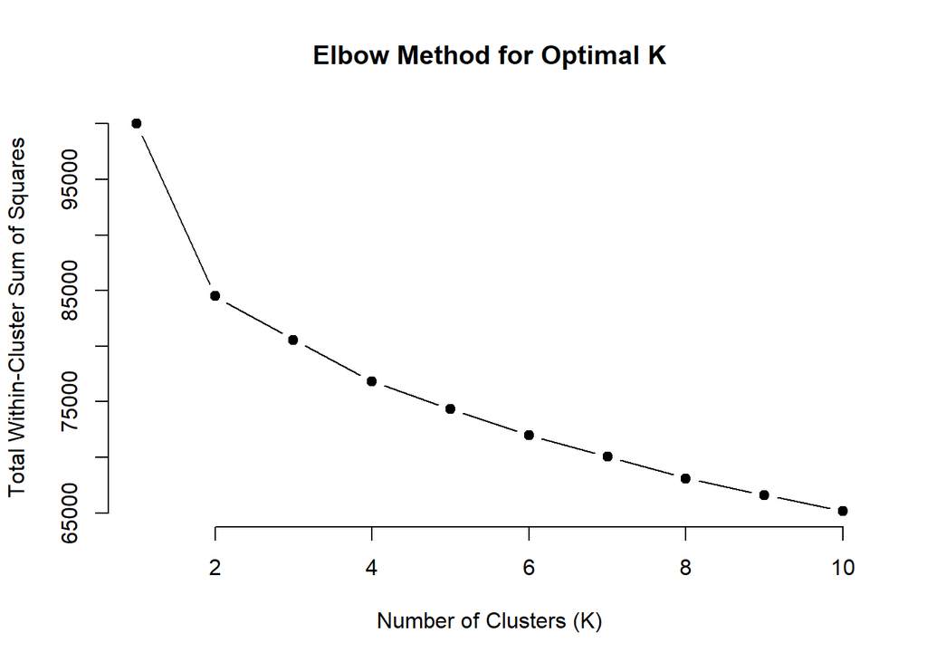

```r
# Select and standardize numerical columns
numerical_cols <- heart_df %>% select(where(is.numeric))

# Impute missing values using column means
numerical_cols <- numerical_cols %>%
  mutate(across(everything(), ~ ifelse(is.na(.), mean(., na.rm = TRUE), .)))

# Standardize numerical columns
numerical_cols_scaled <- scale(numerical_cols)

# Compute Within-Cluster Sum of Squares (WSS) for different k values
set.seed(123)
wss <- sapply(1:10, function(k) {
  kmeans(numerical_cols_scaled, centers = k, nstart = 10)$tot.withinss
})

# Plot Elbow Method to determine the optimal number of clusters
plot(1:10, wss, type = "b", pch = 19, frame = FALSE,
     xlab = "Number of Clusters (K)", ylab = "Total Within-Cluster Sum of Squares",
     main = "Elbow Method for Optimal K")
```

```r
# Choose optimal K (from the elbow plot)
optimal_k <- 3  # Adjust this based on the plot

# Apply K-Means Clustering
set.seed(123)
kmeans_model <- kmeans(numerical_cols_scaled, centers = optimal_k, nstart = 25)

# Add cluster labels to the original dataset
heart_df$Cluster <- as.factor(kmeans_model$cluster)

# View the first few rows with the new Cluster feature
head(heart_df)
```

```
  Age Gender Blood.Pressure Cholesterol.Level Exercise.Habits Smoking
1  56   Male            153               155            High     Yes
2  69 Female            146               286            High      No
3  46   Male            126               216             Low      No
4  32 Female            122               293            High     Yes
5  60   Male            166               242             Low     Yes
6  25   Male            152               257             Low     Yes
  Family.Heart.Disease Diabetes      BMI High.Blood.Pressure
1                  Yes       No 24.99159                 Yes
2                  Yes      Yes 25.22180                  No
3                   No       No 29.85545                  No
4                  Yes       No 24.13048                 Yes
5                  Yes      Yes 20.48629                 Yes
6                   No       No 28.14468                  No
  Low.HDL.Cholesterol High.LDL.Cholesterol Alcohol.Consumption Stress.Level
```

[output cut: 27 more lines]

# 11 **Principal Component Analysis (PCA)**

## 11.3 **Implications**

```r
# Select only numerical features
numerical_cols <- heart_df %>% select(where(is.numeric))

# Handle missing values by imputing with column means
numerical_cols <- numerical_cols %>%
  mutate(across(everything(), ~ ifelse(is.na(.), mean(., na.rm = TRUE), .)))

# Standardize the data (important for PCA)
numerical_cols_scaled <- scale(numerical_cols)

# Apply PCA
pca_model <- prcomp(numerical_cols_scaled, center = TRUE, scale. = TRUE)

# View summary of PCA results
summary(pca_model)
```

```
Importance of components:
                         PC1    PC2    PC3    PC4    PC5     PC6     PC7
Standard deviation     1.404 1.0202 1.0197 1.0066 1.0006 0.99405 0.98851
Proportion of Variance 0.197 0.1041 0.1040 0.1013 0.1001 0.09881 0.09771
Cumulative Proportion  0.197 0.3011 0.4051 0.5064 0.6065 0.70532 0.80304
                           PC8    PC9    PC10
Standard deviation     0.98787 0.9808 0.17807
Proportion of Variance 0.09759 0.0962 0.00317
Cumulative Proportion  0.90063 0.9968 1.00000
```